# War & Markets: How Global Conflict Shapes Stock Performance

DATA 332 Project Showcase

Author

Samyam Bista

Published

April 25, 2026

# Page 1: Project Definition

## Project Goals

This project investigates how major geopolitical conflict events between 2025 and 2026 impacted stock prices across four industries: **Defense**, **Energy**, **Airlines**, and **Consumer Retail**. Using R and the `tidyquant` package, live historical stock data is fetched directly from Yahoo Finance with no external file download required.

**Three core questions drive the analysis:**

- Which industries consistently gain during war and which consistently lose?
- How quickly does each industry’s stock price react after a conflict event?
- How long does it take each industry to recover back to its pre-war price?

## Stocks & Conflict Events Studied

| Industry | Ticker | Company |
| --- | --- | --- |
| Defense | LMT | Lockheed Martin |
| Defense | RTX | Raytheon |
| Defense | NOC | Northrop Grumman |
| Energy | XOM | ExxonMobil |
| Energy | CVX | Chevron |
| Airlines | DAL | Delta Air Lines |
| Airlines | UAL | United Airlines |
| Retail | AMZN | Amazon |
| Retail | WMT | Walmart |

| Event | Date |
| --- | --- |
| Israel-Iran 12-Day War | Jun 13, 2025 |
| US Joins Iran Conflict | Jun 22, 2025 |
| Operation Southern Spear | Nov 14, 2025 |
| Maduro Captured (Venezuela) | Jan 3, 2026 |
| Full US-Iran War | Feb 28, 2026 |

**Data Source:** Yahoo Finance via `tidyquant::tq_get()` **Date Range:** Jan 2024 – Apr 2026 | **Frequency:** Daily

## Data Summary

| Stock | Industry | Trading Days | Min Price | Max Price | Avg Price | Volatility |
| --- | --- | --- | --- | --- | --- | --- |
| AMZN | Consumer Retail | 563 | $144.57 | $254 | $203.15 | 2% |
| CVX | Energy | 563 | $127.97 | $211.15 | $148.18 | 1% |
| DAL | Airlines | 563 | $35.44 | $75.15 | $53.33 | 3% |
| LMT | Defense | 563 | $393.78 | $676.70 | $480.85 | 1% |
| NOC | Defense | 563 | $411.49 | $768.02 | $515.20 | 2% |
| RTX | Defense | 563 | $81.28 | $212.16 | $132.86 | 1% |
| UAL | Airlines | 563 | $37.88 | $117.53 | $77.10 | 3% |
| WMT | Consumer Retail | 563 | $51.02 | $133.62 | $87.93 | 1% |
| XOM | Energy | 563 | $89.70 | $171.47 | $111.89 | 1% |

# Page 2: Methodology & Visualizations

## Chart 1: Cumulative Returns by Industry with Conflict Event Markers

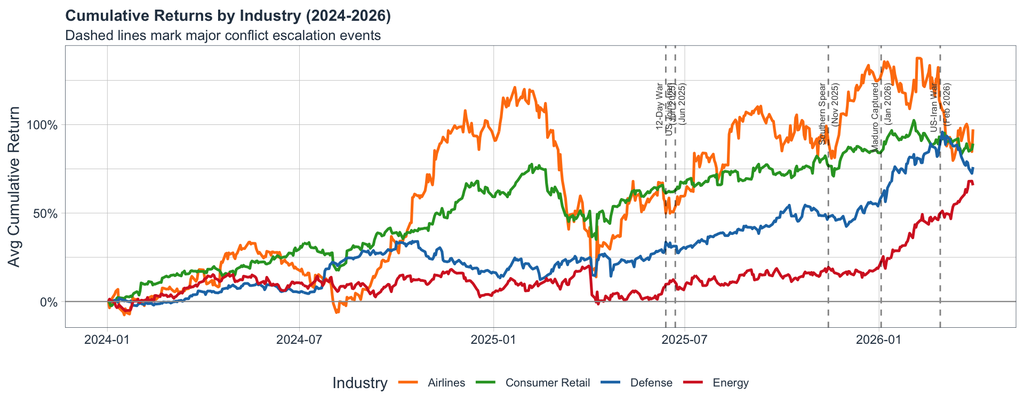

## Chart 2: 30-Day Rolling Volatility

[figure not shown]